# Homework II - Basketball

Bayesian Data Analysis

Alexander J Ohrt

22 mars, 2022

# a) Compare the Number of Points in NBA vs. ACB

In order to compare the number of points scored in a match in NBA with a match in ACB I will specify a poisson model for both the two match types, with a gamma prior distribution for the parameter in each case

- NBA

$$Y \sim Poisson(\lambda_{1})$$

$$\lambda_1 \sim Gamma(\alpha_1, \beta_1)$$

- ACB

$$Y \sim Poisson(\lambda_{2})$$

$$\lambda_2 \sim Gamma(\alpha_2, \beta_2)$$

After some quick research on how many points are usual in the NBA and ACB, I have chosen the following shape ($\alpha$) and rate ($\beta$) parameters for the priors

$$\alpha_1 = 200, \beta_1 = 1, \alpha_2 = 160, \beta_2 = 1$$

# b) Plot Priori, Likelihood and Posteriori

First, we read the data we are given on 20 random games in each of the two leagues.

```r
data <- read.table("basquet.txt", header = T)
str(data)
```

```
#> 'data.frame':    20 obs. of  2 variables:
#>  $ acb: int  161 161 169 164 180 157 154 157 158 182 ...
#>  $ nba: int  199 208 189 183 192 210 199 217 210 204 ...
```

```r
head(data)
```

```
#>   acb nba
#> 1 161 199
#> 2 161 208
#> 3 169 189
#> 4 164 183
#> 5 180 192
#> 6 157 210
```

The prior, likelihood and posteriori are calculated and plotted below.

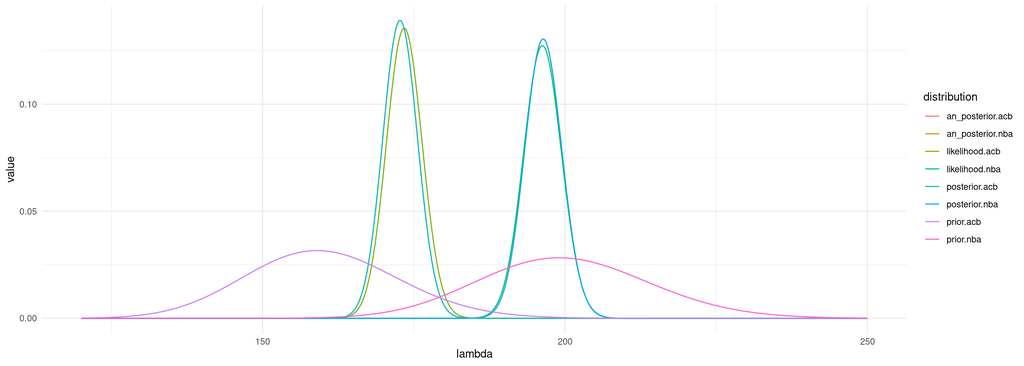

```r
delta.lambda <- 0.005
start <- 120
end <- 250
sim.points <- (end-start)/delta.lambda
lambda <- seq(start, end, length.out = sim.points)
n <- dim(data)[[1]]

prior.par.nba <- c(alpha = 200, beta = 1)
prior.par.acb <- c(alpha = 160, beta = 1)

prior.nba <- dgamma(lambda, shape = prior.par.nba[1], rate = prior.par.nba[2])
prior.acb <- dgamma(lambda, shape = prior.par.acb[1], rate = prior.par.acb[2])

#likelihood.nba <- exp(-lambda*n)*lambda^sum(data[,2])
likelihood.nba <- map_dbl(lambda, ~ prod(dpois(data[,2], .x)))
likelihood.nba <- likelihood.nba/(sum(likelihood.nba)*delta.lambda)
#likelihood.acb <- exp(-lambda*n)*lambda^sum(data[,1])
likelihood.acb <- map_dbl(lambda, ~ prod(dpois(data[,1], .x)))
likelihood.acb <- likelihood.acb/(sum(likelihood.acb)*delta.lambda)

# Simulated posterior
prod.nba <- likelihood.nba*prior.nba
posterior.nba <- prod.nba/(sum(prod.nba)*delta.lambda)
prod.acb <- likelihood.acb*prior.acb
posterior.acb <- prod.acb/(sum(prod.acb)*delta.lambda)

# Analytical solution of posterior (conjugate prior)
posterior.par.nba <- prior.par.nba + c(sum(data[,2]), n)
posterior.par.acb <- prior.par.acb + c(sum(data[,1]), n)
an_posterior.nba <- dgamma(lambda, shape = posterior.par.nba[1], rate = posterior.par.nba[2])
an_posterior.acb <- dgamma(lambda, shape = posterior.par.acb[1], rate = posterior.par.acb[2])

df <- tibble(lambda, likelihood.nba, likelihood.acb,
             prior.nba, prior.acb,
             an_posterior.nba, an_posterior.acb,
             posterior.nba, posterior.acb)

df2 <- df %>%
    gather(key = distribution, value = value, -lambda)

df3 <- df2 %>%
    separate(distribution, into = c("distribution", "league"), sep = "\\.")

df2 %>%
    ggplot() +
    geom_line(aes(x = lambda, y = value, col = distribution))
```

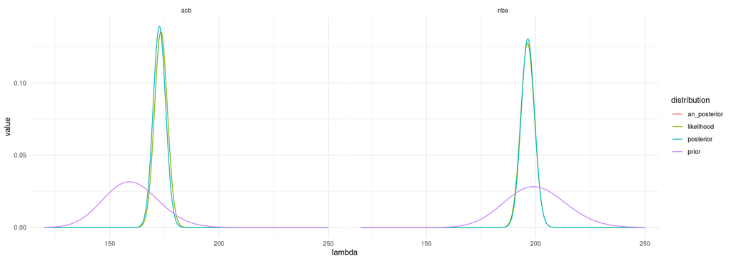

```r
df3 %>%
    ggplot() +
    geom_line(aes(x = lambda, y = value, col = distribution)) +
    facet_wrap(~league)
```

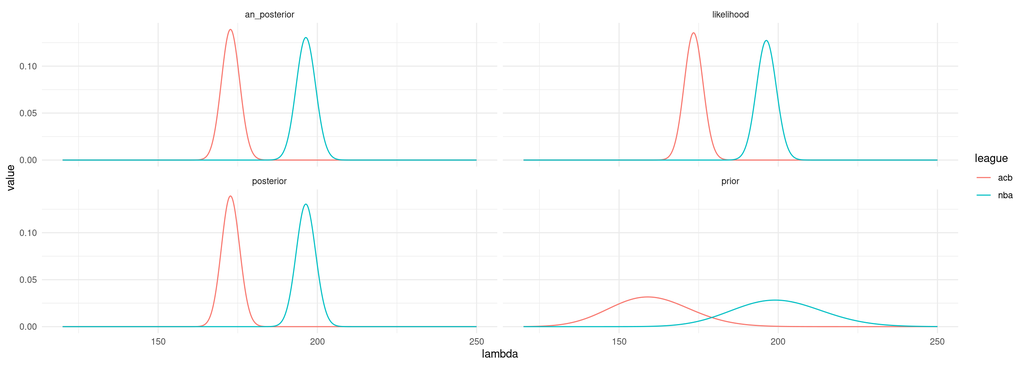

```r
df3 %>%
    ggplot() +
    geom_line(aes(x = lambda, y = value, col = league)) +
    facet_wrap(~distribution)
```

# Probabilities

In order to answer the following probability questions we have to calculate the posterior predictive distribution. I will do this by simulating values, using the posterior we found earlier.

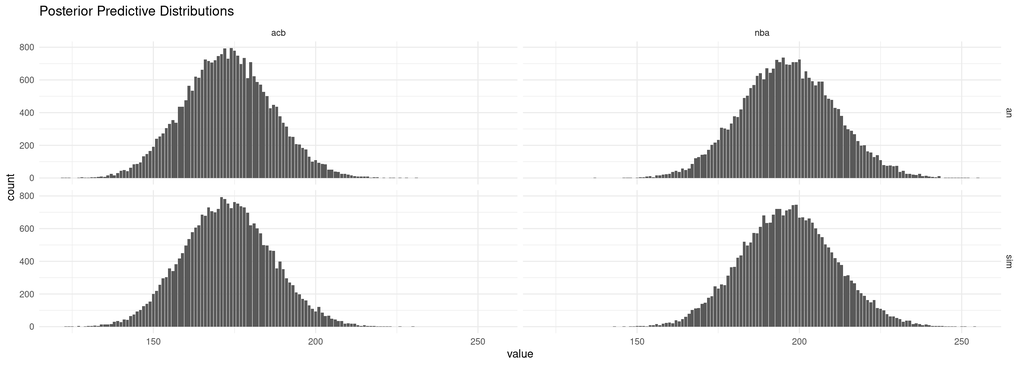

```r
seed <- 1
set.seed(seed)
post.an.nba <- rgamma(sim.points, shape = posterior.par.nba[1], rate = posterior.par.nba[2])
set.seed(seed)
y.post.sim1an_nba <- rpois(sim.points, lambda = post.an.nba) # First using simulated values from the analytical posterior (conjugate)

set.seed(seed)
post.samples.nba <- sample(lambda, size = sim.points, replace = T, prob = posterior.nba)
set.seed(seed)
y.post.sim1sim_nba <- rpois(sim.points, lambda = post.samples.nba) # Secondly using samples from the simulated posterior from earlier.

set.seed(seed)
post.an.acb <- rgamma(sim.points, shape = posterior.par.acb[1], rate = posterior.par.acb[2])
set.seed(seed)
y.post.sim1an_acb <- rpois(sim.points, lambda = post.an.acb) # First using simulated values from the analytical posterior (conjugate).

set.seed(seed)
post.samples.acb <- sample(lambda, size = sim.points, replace = T, prob = posterior.acb)
set.seed(seed)
y.post.sim1sim_acb <- rpois(sim.points, lambda = post.samples.acb) # Secondly using samples from the simulated posterior from earlier.

df4 <- tibble(y.post.sim1an_nba, y.post.sim1sim_nba, y.post.sim1an_acb, y.post.sim1sim_acb)
df5 <- df4 %>%
    gather(key = distribution, value = value)

df6 <- df5 %>%
    separate(distribution, into = c("distribution", "league"), sep = "_") %>%
    separate(distribution, into = c("distribution", "vers"), sep = "1")

# Plotting the posterior predictive probabilities.
df6 %>%
    ggplot() +
    geom_bar(aes(x = value)) +
    facet_grid(row = vars(vers), col = vars(league)) +
    ggtitle("Posterior Predictive Distributions")
```

Both versions of the (simulated) posterior predictive distributions look very similar.

Let us also calculate the difference between the two posterior predictive distributions and plot it. This will come in handy when answering the following questions.

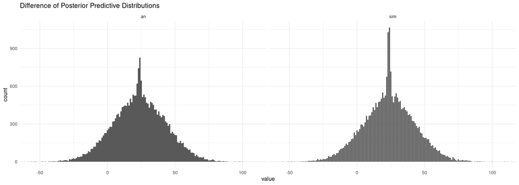

```r
diff.sim <- y.post.sim1sim_nba - y.post.sim1sim_acb
diff.an <- y.post.sim1an_nba - y.post.sim1an_acb

df7 <- tibble(diff.sim, diff.an)
df8 <- df7 %>%
    gather(key = distribution, value = value)

df9 <- df8 %>%
    separate(distribution, into = c("distribution", "vers"), sep = "\\.")

# Plotting the posterior predictive probabilities.
df9 %>%
    ggplot() +
    geom_bar(aes(x = value)) +
    facet_wrap(~vers) +
    ggtitle("Difference of Posterior Predictive Distributions")
```

## c)

What is the probability that more points will be scored in a randomly selected match of the Spanish league than in a randomly selected match of the NBA league?

```r
mean(diff.sim < 0)
```

```
#> [1] 0.1000769
```

```r
mean(diff.an < 0)
```

```
#> [1] 0.1053846
```

The probabilities are given above, first based on the “fully simulated version” and second based on the “halfway simulated version”.

## d)

What is the probability that the points scored in a NBA match will be 60 points or more larger than the points scored in an ACB match?

```r
mean(diff.sim >= 60)
```

```
#> [1] 0.03
```

```r
mean(diff.an >= 60)
```

```
#> [1] 0.03276923
```

The probabilities are given above, first based on the “fully simulated version” and second based on the “halfway simulated version”.